# Plotting in R

MRC London Institute of Medical Sciences (LMS)  
https://lmsbioinformatics.github.io/LMS_PlottingInR/

### Materials.

All prerequisites, links to material and slides for this course can be found on github.

- [PlottingInR](https://lmsbioinformatics.github.io/LMS_PlottingInR/)

Or can be downloaded as a zip archive from here.

- [Download zip](https://github.com/LMSBioinformatics/LMS_PlottingInR/archive/master.zip)

### Set the Working directory

Before running any of the code in the practicals or slides we need to set the working directory to the folder we unarchived.

You may navigate to the unarchived LMS_PlottingInR/course folder in the Rstudio menu

**Session -> Set Working Directory -> Choose Directory**

[figure not shown]

### Set working directory - in the console

Use getwd() to see where your current directory is

```r
getwd()
```

```r
setwd("/PathToMyDownload/LMS_PlottingInR/course")
# e.g. setwd("~/Downloads/LMS_PlottingInR/course")
```

## Plotting in R

### Introduction

R has excellent graphics and plotting capabilities. They are mostly found in following three sources.

- base graphics

  easy to use, conceptually motivated by drawing on a canvas

  would become difficult or impossible to draw complicated plots
- the lattice package
- the ggplot2 package

  high-level approach: grammar of graphics
- saving your plots

Lattice and ggplot2 packages are built on grid graphics package while the base graphics routines adopt a pen and paper model for plotting.

We will start from the base graphics then focus on ggplot2

## R Base Graphics

### Base Graphics

- Line Charts

First we'll produce a very simple graph using the values in the data.frame that we created:

```r
base_graph_df<- data.frame(sample_num=c(1:6),
                           treatment=c(0.02,1.8, 17.5, 55,75.7, 80),
                           control= c(0, 20, 40, 60, 80,100))

base_graph_df
```

```
  sample_num treatment control
1          1      0.02       0
2          2      1.80      20
3          3     17.50      40
4          4     55.00      60
5          5     75.70      80
6          6     80.00     100
```

### Base Graphics

- Line Charts

Plot the treatment with default parameters

```r
?plot
```

```
* Usage

plot(x, y, ...)
```

```r
plot(base_graph_df$sample_num, base_graph_df$treatment)
```

### Line Plot

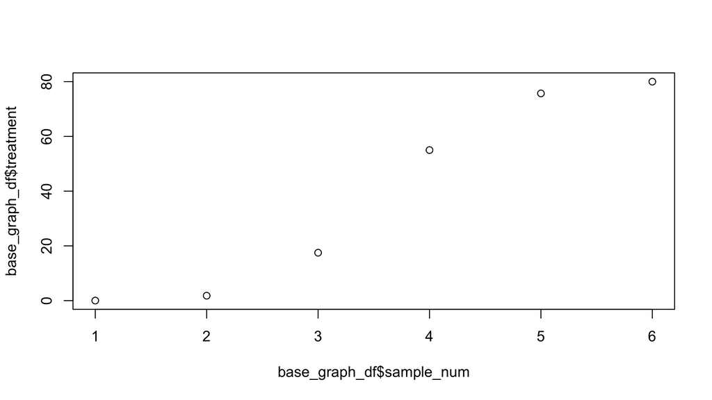

Now, let's add a **title**, a **line to connect the points**, and some **colour**:

Plot treatment using blue points overlayed by a line

hint: look into the “type” argument

```r
?plot
```

## Arguments

- type: what type of plot should be drawn. Possible types are

  ```
  "p" for points,
  "l" for lines,
  "b" for both,
  "c" for the lines part alone of "b",
  "o" for both ‘overplotted’,
  "h" for ‘histogram’ like (or ‘high-density’) vertical lines,
  "s" for stair steps,
  "S" for other steps, see ‘Details’ below,
  "n" for no plotting.
  ```

```r
plot(base_graph_df$sample_num,base_graph_df$treatment, type="o", col="blue")
```

Create a title with a red, bold/italic font

hint: 1=plain, 2=bold, 3=italic, 4=bold italic, 5=symbol

```r
title(main="Treatment", col.main="red", font.main=4)
```

### Line Plot

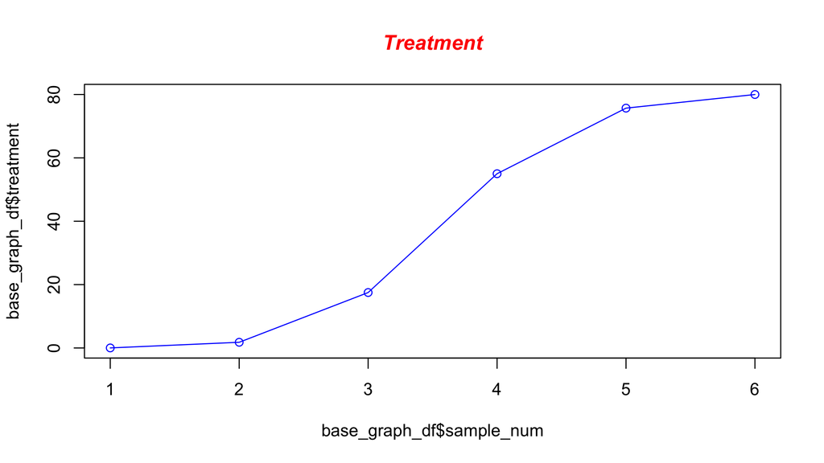

Now let's add a **red line for control column** from the data.frame **base_graph_df** and **specify the y-axis range** directly so it will be large enough to fit the data:

- show the control information

```r
base_graph_df$control
```

```
[1]   0  20  40  60  80 100
```

- Plot **treatment** using a y axis that ranges from 0 to 100

```r
plot(base_graph_df$sample_num,base_graph_df$treatment, type="o", col="blue", ylim=c(0,100))
```

- Plot **control** with **red dashed line** and **square points** [hint: pch=0]

```r
lines(base_graph_df$control, type="o", pch=0, lty="dashed", col="red")
```

- Create a title with a red, bold/italic font

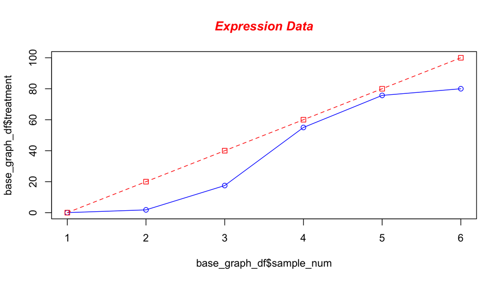

```r
title(main="Expression Data", col.main="red", font.main=4)
```

### Plotting ‘character’ (pch) - symbol to use

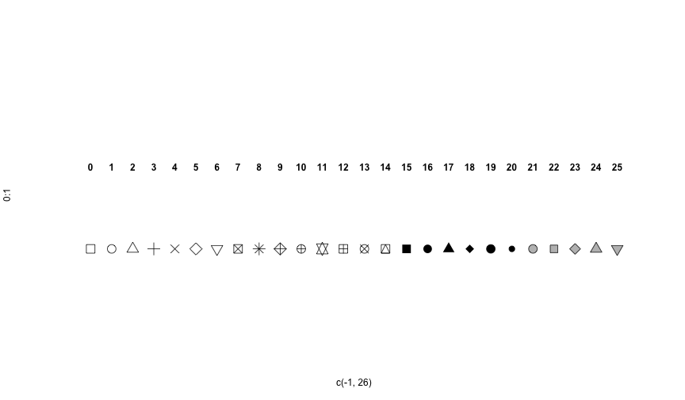

### The line type - lty

lty can be c(“blank”,solid", “dashed”, “dotted”, “dotdash”, “longdash”, “twodash”) or number c(0, 1, 2, 3, 4, 5, 6)

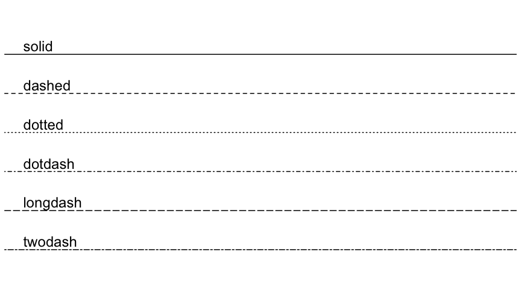

### change axes labels, colour and add legend

Next let's change the axes labels to match our data and add a legend.

We'll also compute the y-axis values using the max function so any changes to our data will be automatically reflected in our graph.

- Calculate range from 0 to max value of data

```r
g_range <- range(0, base_graph_df$treatment, base_graph_df$control)
g_range
```

```
[1]   0 100
```

range returns a vector containing the minimum and maximum of all the given arguments.

- Plot treatment using y axis that ranges from 0 to max value in treatment or control vector. Turn off axes and annotations (axis labels) so we can specify them ourselves.

```r
plot(base_graph_df$sample_num ,base_graph_df$treatment,
     type="o", col="blue",
     ylim=g_range,axes=FALSE, ann=FALSE)
```

Make x axis using labels

```r
axis(1, at=1:6, lab=base_graph_df$sample_num)
```

Make y axis with horizontal labels that display ticks at every 20 marks.

```r
axis(2, las=1, at=20*0:g_range[2])
```

Create box around plot

```r
box()
```

Plot control vector with red dashed line and square points

```r
lines(base_graph_df$control, type="o", pch=22, lty=2, col="red")
```

Create a title with a red, bold/italic font

```r
title(main="Data", col.main="red", font.main=4)
```

```r
title(xlab="Samples", col.lab="purple")
title(ylab="Values", col.lab="purple")
```

Create a legend at (1, g_range[2]) that is slightly smaller (cex) and uses the same line colors and points used by the actual plots

[figure not shown]

```r
legend(1, g_range[2], c("treatment","control"), cex=0.8, col=c("blue","red"), pch=21:22, lty=1:2);
```

## ggplot2 R package

ggplot2 is a powerful R package based on the grammar of graphics (Wilkinson, 2005).

“In brief, the grammar tells us that a statistical graphic is a mapping from data to aesthetic attributes (colour, shape, size) of geometric objects (points, lines, bars).” - Wickham, 2016

### ggplot2 R package

We'll use the **GoT_dataset** that kindly provided by Dr. Reidar P. Lystad. Inj Epidemiol. 2018. 5(1):44. doi: 10.1186/s40621-018-0174-7. (https://figshare.com/articles/Game_of_Thrones_mortality_and_survival_dataset/8259680)

We can use the head function to look at the first few rows of file “episode_data.csv”

```r
library(ggplot2)
episode_data<-read.csv("GoT_dataset/episode_data.csv")

head(episode_data)
```

```
  season episode_number                            episode_name
1      1              1                      "Winter Is Coming"
2      1              2                         "The Kingsroad"
3      1              3                             "Lord Snow"
4      1              4 "Cripples, Bastards, and Broken Things"
5      1              5                 "The Wolf and the Lion"
6      1              6                        "A Golden Crown"
  gross_running_time opening_credits_time closing_credits_time
1               3546                  110                   33
2               3182                  111                   34
3               3294                   96                   27
4               3201                   96                   26
5               3123                  101                   24
6               3027                  103                   26
  net_running_time cumulative_net_running_time
1             3403                        3403
2             3037                        6440
3             3171                        9611
4             3079                       12690
5             2998                       15688
6             2898                       18586
```

## Every ggplot2 plot has three key components:

```
1. data,

2. aesthetic mappings between variables in the data and visual
properties, and

3. layer: usually created with a geom function.
```

use ggplot2's ggplot() function to setup **data** and **aesthetic mappings**

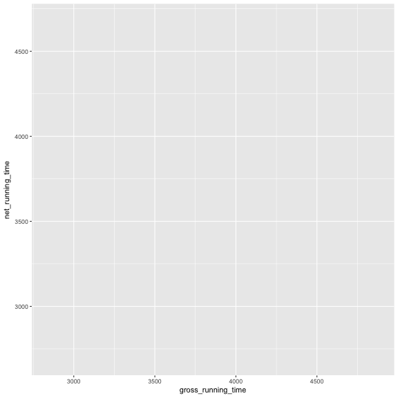

```r
g<-ggplot(data=episode_data,
          aes(x=gross_running_time,y=net_running_time))

print(g)
```

### add geom_point layer - Scatter plot

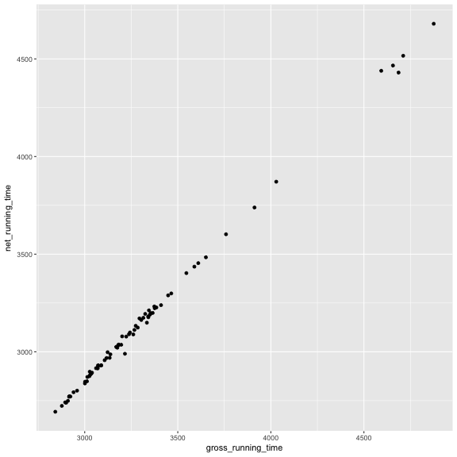

```r
g<-ggplot(data=episode_data,
          aes(x=gross_running_time,y=net_running_time))
g + geom_point()
```

### add geom_histogram layer - Histogram plot (1/2)

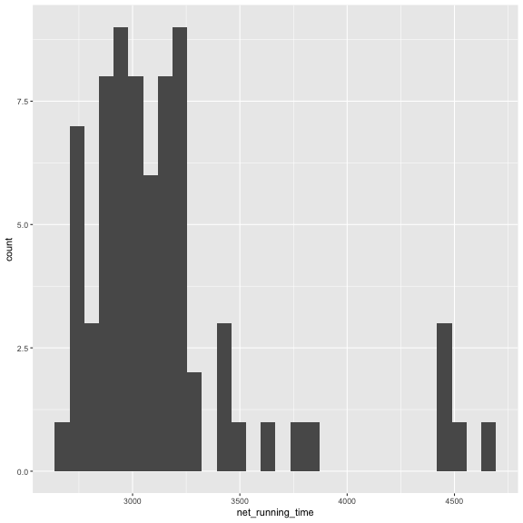

```r
ghis<-ggplot(data=episode_data, aes(x=net_running_time))
ghis + geom_histogram()
```

### add geom_histogram layer - Histogram plot (2/2)

change binwidth

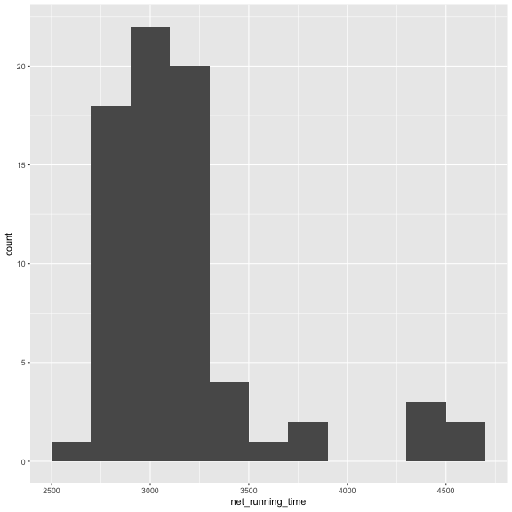

```r
#ghis<-ggplot(data=episode_data, aes(x=net_running_time))
ghis + geom_histogram(binwidth=200)
```

### add geom_density layer - Density plot (1/3)

add geom_density layer

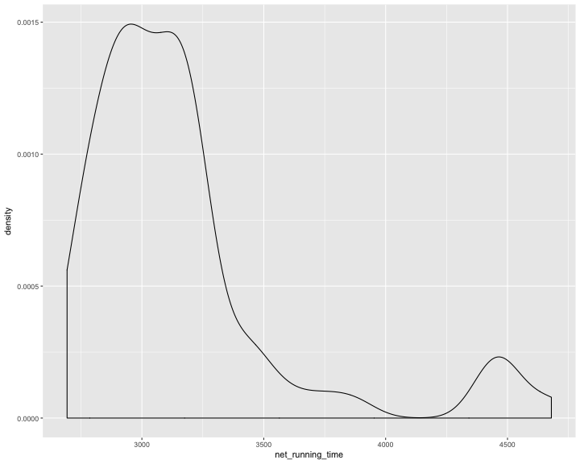

```r
ghis<-ggplot(data=episode_data, aes(x=net_running_time))
ghis + geom_density()
```

### add geom_density layer - Density plot (2/3)

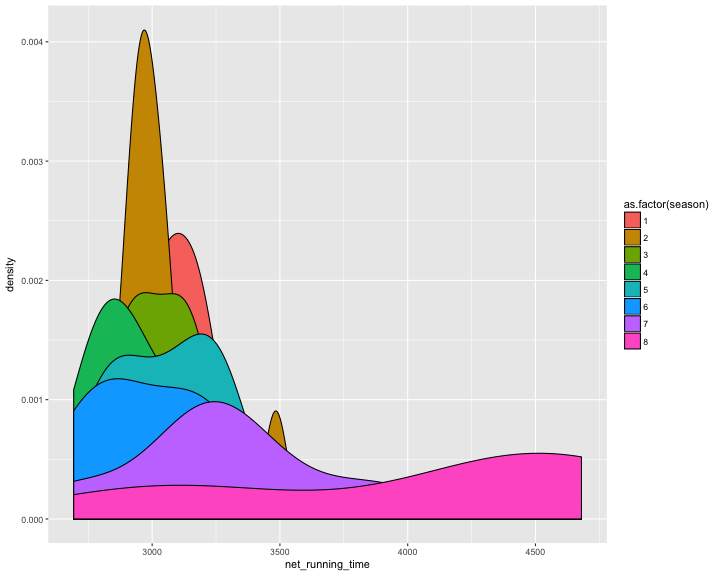

```r
ghis<- ggplot(data=episode_data,
              aes(x=net_running_time,fill=as.factor(season)))
ghis + geom_density()
```

### add geom_density layer - Density plot (3/3)

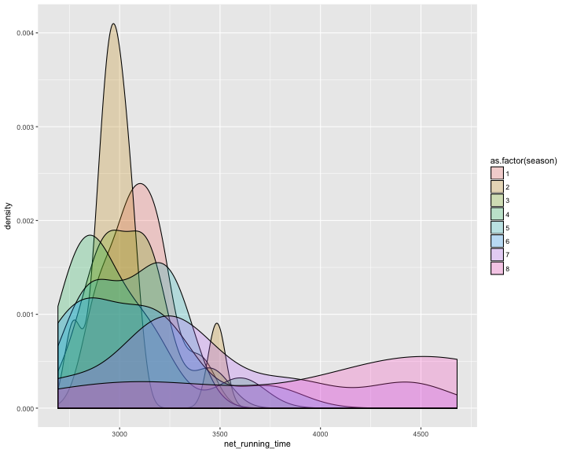

```r
ghis<- ggplot(data=episode_data,
              aes(x=net_running_time,fill=as.factor(season)))
ghis + geom_density(alpha=0.25)
```

### Bar plot (1/4) - geom_bar()

add geom_bar layer

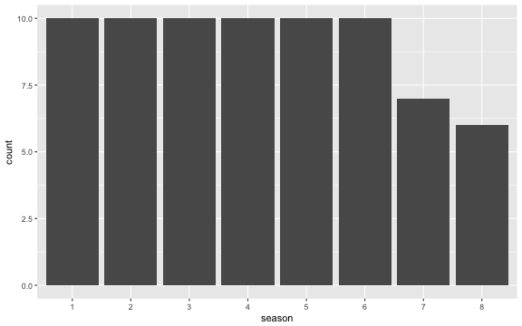

```r
episode_data$season<-as.factor(episode_data$season)
gbar<- ggplot(data=episode_data, aes(x=season))
gbar + geom_bar()
```

### Bar plot (2/4) - change labels for x,y axes and add title

use xlab(), ylab(), and ggtitl()

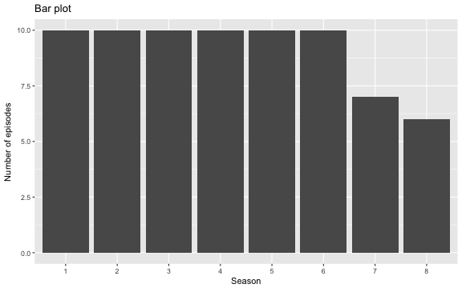

```r
gbar<- ggplot(data=episode_data, aes(x=season))
gbar + geom_bar() +
  xlab("Season")+ ylab("Number of episodes")+ ggtitle("Bar plot")
```

### Bar plot (3/4) - change labels for x,y axes and add title

or just use labs()

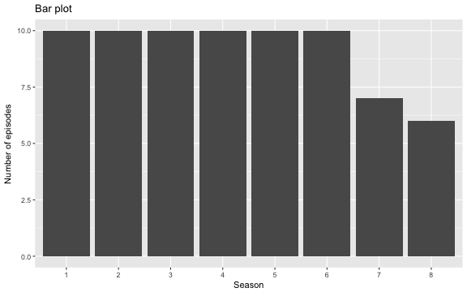

```r
gbar<- ggplot(data=episode_data, aes(x=season))
gbar + geom_bar() +
  labs(x="Season",y="Number of episodes",title="Bar plot")
```

### Bar plot (4/4) - coord_flip ()

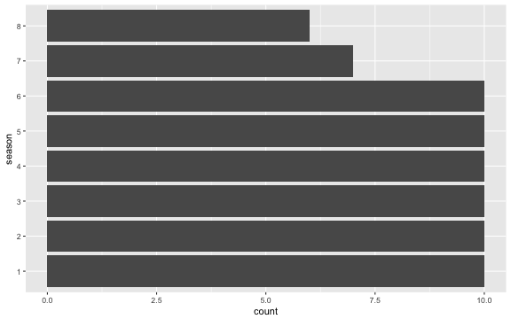

```r
gbar + geom_bar() + coord_flip()
```

### Exercise

Time for exercise -

- Plotting in R exercise 1

### Solutions

- Plotting in R solution 1

### Box plot (1/7) - use geom_boxplot()

```r
subset_GoT<-read.csv(file="Got_dataset/subset_GoT.csv")

head(subset_GoT)
```

```
   id         name sex        religion            occupation social_status
1 100 Waymar Royce   M Unknown/Unclear Boiled leather collar       Lowborn
2 101 Gared Tuttle   M Unknown/Unclear Boiled leather collar       Lowborn
3 102         Will   M Unknown/Unclear Boiled leather collar       Lowborn
4 103         Irri   F  Great Stallion Boiled leather collar       Lowborn
5 104     Jon Snow   M        Old Gods Boiled leather collar      Highborn
6 105   Bran Stark   M        Old Gods           Silk collar      Highborn
  allegiance_last allegiance_switched dth_flag exp_time_sec exp_time_hrs
1   Night's Watch                   N        1          342         0.10
2   Night's Watch                   N        1          405         0.11
3   Night's Watch                   N        1          692         0.19
4       Targaryen                   Y        1        48489        13.47
5   Night's Watch                   Y        0       230347        63.99
6           Stark                   N        0       230347        63.99
```

### Box plot (2/7) - use geom_boxplot()

add geom_boxplot layer

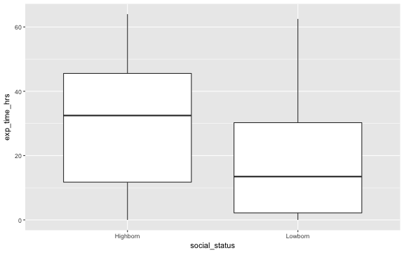

```r
ggplot(data=subset_GoT,aes(x=social_status,y=exp_time_hrs))+
  geom_boxplot()
```

### Box plot (3/7) - geom_point()

add another layer

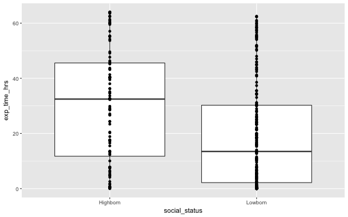

```r
ggplot(data=subset_GoT,aes(x=social_status,y=exp_time_hrs))+
  geom_boxplot() + geom_point()
```

### Box plot (4/7) - position_jitter()

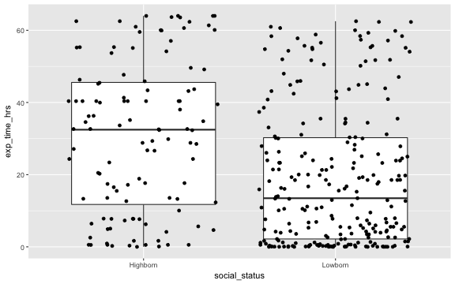

```r
ggplot(data=subset_GoT,aes(x=social_status,y=exp_time_hrs))+
  geom_boxplot() + geom_point(position = position_jitter())
```

### Box plot (5/7) - add colour

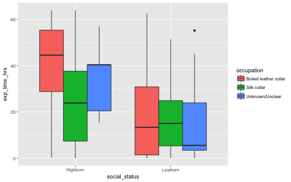

```r
ggplot(data=subset_GoT,aes(x=social_status,y=exp_time_hrs,fill=occupation))+
  geom_boxplot()
```

### Box plot (6/7) - facet_wrap()

add facet_wrap() layer

facet_wrap(~variable)

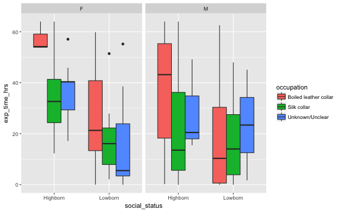

```r
ggplot(data=subset_GoT,aes(x=social_status,y=exp_time_hrs,fill=occupation))+
  geom_boxplot()+facet_wrap(~sex)
```

### Box plot (7/7) - facet_grid()

add facet_grid() layer

facet_grid(Rows.for.var1~Columns.for.var2)

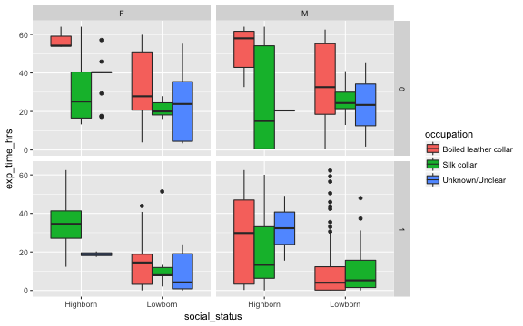

```r
ggplot(data=subset_GoT,aes(x=social_status,y=exp_time_hrs,fill=occupation))+
  geom_boxplot()+facet_grid(dth_flag~sex)
```

### Saving your plots - ggsave

- It defaults to saving the last plot that you displayed, using the size of the current graphics device
- It also guesses the type of graphics device from the extension
- device: “eps”, “ps”, “tex” (pictex), “pdf”, “jpeg”, “tiff”, “png”, “bmp”, “svg” or “wmf” (windows only)

### Saving your plots - ggsave (1/2)

```r
ggplot(mtcars, aes(mpg, wt)) + geom_point()
ggsave("mtcars_default.pdf")
ggsave("mtcars.pdf", width = 4, height = 4)
```

### Saving your plots - ggsave (2/2)

Plot to save, defaults to last plot displayed.

ggsave(filename, plot = last_plot(), device = NULL, path = NULL, scale = 1, width = NA, height = NA, units = c(“in”, “cm”, “mm”), dpi = 300, limitsize = TRUE, …)

```r
plot1<-ggplot(mtcars, aes(mpg, wt)) + geom_point()
plot2<-ggplot(mtcars, aes(mpg, wt,col=as.factor(vs))) + geom_point()

ggsave("mtcars_default.png",plot1)
ggsave("mtcars_col.png",plot2)
```

### Summary

- Visualization of data through charts and graphs is an essential part of data analysis process, so R has excellent tools for creating graphics.
- There are many different ways of making plots in R including base graphics and R packages such as lattics and ggplot2.
- Use vast arrays of R packages available to create publication quality graphs.

### Base Graphics VS ggplot2 (1/5)

Base Graphic 1

```
  sample_num treatment control
1          1      0.02       0
2          2      1.80      20
3          3     17.50      40
4          4     55.00      60
5          5     75.70      80
6          6     80.00     100
```

[figure not shown]

```r
base_graph_df
```

### Base Graphics VS ggplot2 (2/5)

Base Graphic 2

```r
plot(base_graph_df$sample_num ,base_graph_df$treatment, type="o", col="blue", ylim=g_range,axes=FALSE, ann=FALSE)
axis(1, at=1:6, lab=base_graph_df$days)
axis(2, las=1, at=20*0:g_range[2])
box()

lines(base_graph_df$control, type="o", pch=22, lty=2, col="red")
title(main="Expression Data", col.main="red", font.main=4)
title(xlab="Samples", col.lab="purple")
title(ylab="Values", col.lab="purple")
legend(1, g_range[2], c("treatment","control"), cex=0.8, col=c("blue","red"), pch=21:22, lty=1:2);
```

### Base Graphics VS ggplot2 (3/5)

ggplot2 - prepare the data.frame

```r
# covert data.frame into the format that ggplot likes
# install.packages("reshape2")
library("reshape2")

base_graph_4gg<-melt(base_graph_df, id.vars="sample_num")
base_graph_4gg$variable<-relevel(base_graph_4gg$variable,ref="control")
head(base_graph_4gg,n=10)
```

```
   sample_num  variable value
1           1 treatment  0.02
2           2 treatment  1.80
3           3 treatment 17.50
4           4 treatment 55.00
5           5 treatment 75.70
6           6 treatment 80.00
7           1   control  0.00
8           2   control 20.00
9           3   control 40.00
10          4   control 60.00
```

### Base Graphics VS ggplot2 (4/5)

ggplot2 - plot the figure with default settings

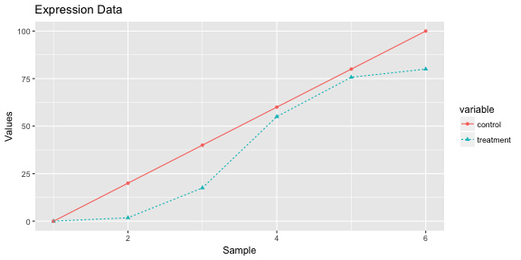

```r
library("ggplot2")

ggplot(base_graph_4gg,aes(x=sample_num,y=value,col=variable,group=variable)) +
  geom_point(aes(shape=variable))+
  geom_line(aes(linetype=variable))+
  labs(title="Expression Data",x ="Sample", y = "Values")
```

### Base Graphics VS ggplot2 (5/5)

ggplot2 - plot the figure that matches base grahpics

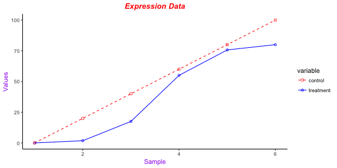

```r
ggplot(base_graph_4gg,aes(x=sample_num,y=value,col=variable,group=variable)) +
  geom_point(aes(shape=variable))+
  geom_line(aes(linetype=variable))+
  scale_color_manual(values=c("red", "blue"))+
  scale_shape_manual(values=c(0,1))+
  scale_linetype_manual(values=c("dashed","solid"))+
  labs(title="Expression Data",x ="Sample", y = "Values")+
  theme_classic()+
  theme(plot.title = element_text(colour = "red",face="bold.italic",hjust = 0.5),
        axis.title = element_text(colour = "purple"))
```

### Exercise

Time for exercise -

- Plotting in R exercise 2

### Solutions

- Plotting in R solution 2

### Combining Plots

R makes it easy to combine multiple plots into one overall graph, using either the par( ) or layout() function. With the par() function, you can include the option mfrow=c(nrows, ncols) to create a matrix of nrows x ncols plots that are filled in by row. mfcol=c(nrows, ncols) fills in the matrix by columns.

Define a layout with 2 rows and 2 columns

```r
par(mfrow=c(2,2))
```

Here, we will use different dataset with two columns each for treated and untreated samples.

```r
data1 <- read.table("data/gene_data.txt", header=T, sep="\t")
head(data1)
```

```
     ensembl_gene_id Untreated1 Untreated2  Treated1   Treated2
1 ENSDARG00000093639  0.8616832  1.9311442 0.1041508 0.14055604
2 ENSDARG00000094508  0.9857575  2.0256352 0.1549917 0.20301609
3 ENSDARG00000095893  0.8498889  1.9875580 0.2317969 0.20925123
4 ENSDARG00000095252  0.9242996  2.0857620 0.2562264 0.24669079
5 ENSDARG00000078878  0.3571734  0.4653908 0.1167221 0.09710237
6 ENSDARG00000079403  1.0604071  1.2581398 0.3884836 0.31567299
```

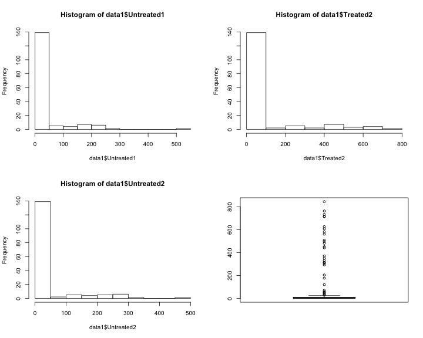

```r
hist(data1$Untreated1)
hist(data1$Treated2)
hist(data1$Untreated2)
boxplot(data1$Treated1)
```

Recover the original settings

```r
par(mfrow=c(1,1))
```